# Glaucous-wing Gull data & maps

Author

Thor Veen

## Data sources

I compiled data from two sources, King, Blight and Bertram 2020 (KBB2020 [pdf](https://figshare.com/articles/figure/Glaucous-winged_Gull_nesting_sites_in_the_Strait_of_Georgia_BC_Canada_/13530971/1), data provided in spreadsheet with fig share) and Rodway, Campbell and Lemon 2023 (SCoBC2023 [link](http://www.wildlifebc.org/), data scraped from table 6). Using KBB2020 as the most recent and comprehensive benchmark for GWGU, I added to this dataset the information of additional colonies from SCoBC2023. I match the location codes and cross referenced location names with SCoBC2023 to make the final dataset as compatible as possible with other and future resources.

In the next section I visualize the occupancy of all known colonies for different periods. Important information to keep in mind when assessing the maps:

- The year mentioned is the start year for which data is included (i.e. 2000 means data from 2000 onwards (>= 2000))
- Each known breeding location of GWGU in the dataset is indicated by a small *black* dot.
- The counts (in *red*) are normalised between 0 (same size dot as black dot) and 10 (biggest colony in the dataset selection, i.e. not the entire dataset necessarily).
- 0 counts are not included to make it easy to see which colonies had active breeding

## Data over time

Histogram showing the number of datapoints over time.

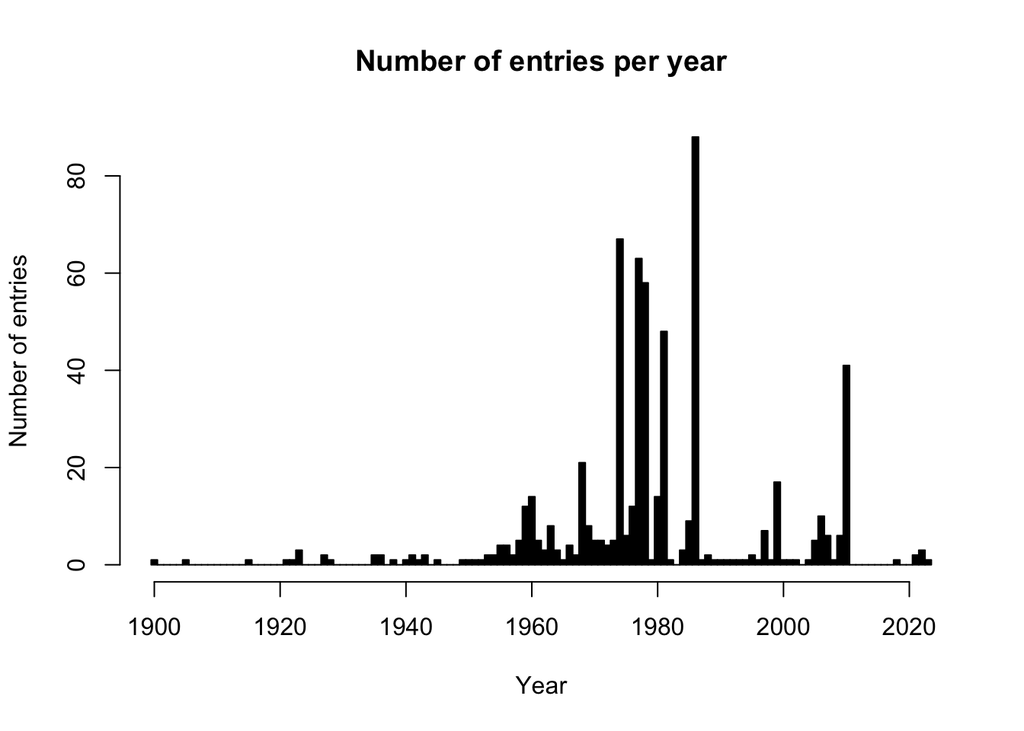

## Maps

An overview map where for each of the 154 known nesting location all the available counts can be seen by clicking on the location dot.

[interactive chart not shown]

### Starting from 2004

Histogram of counts including 0. There are 16 0’s out of the 62 entries from 62 unique colonies in this time period.

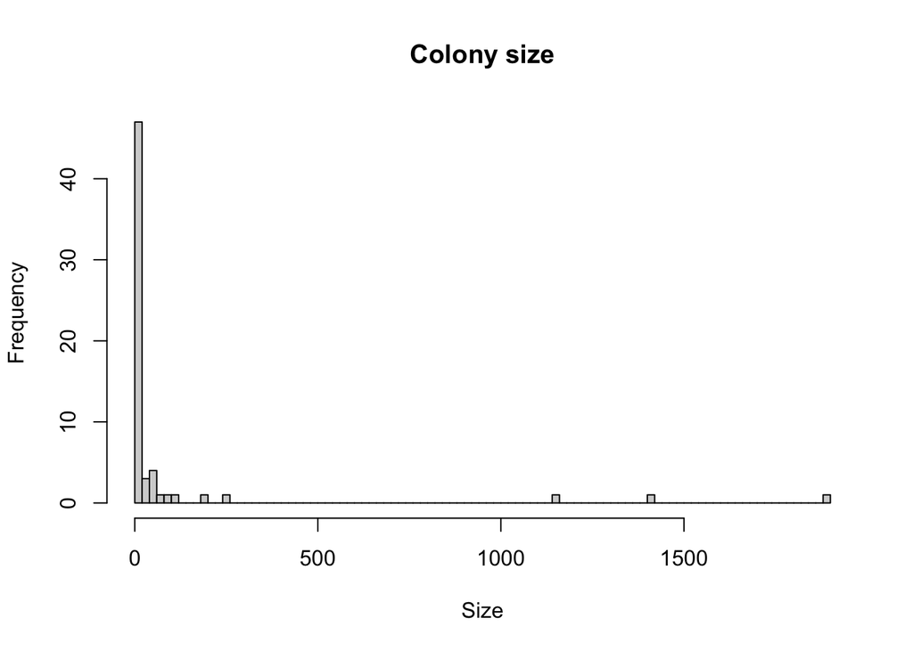

Map (excluding 0)

[interactive chart not shown]

### Starting from 1980

Histogram of counts including 0. There are 20 0’s out of the 122 entries from 122 unique colonies in this time period.

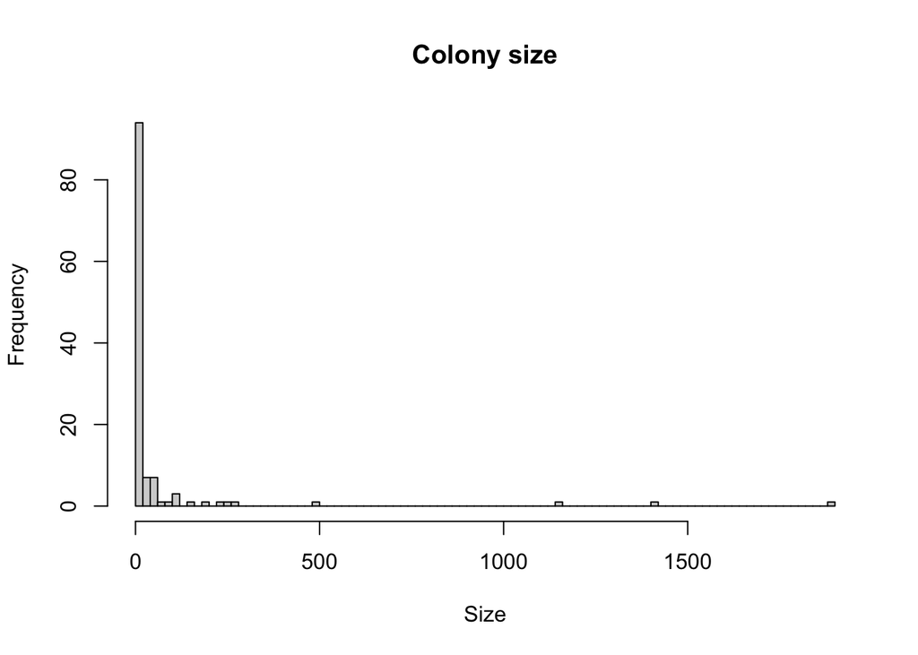

Map (excluding 0)

[interactive chart not shown]

### Smaller colonies focus

The above maps are really dominated by the larger colonies. By added an upper limit to colony size we can see how the medium to smaller colonies are distributed. Focus is on the more recent time period starting from 2004 and max colony size is 500.

Histogram of counts including 0. There are 16 0’s out of the 59 entries from 59 unique colonies in this time period.

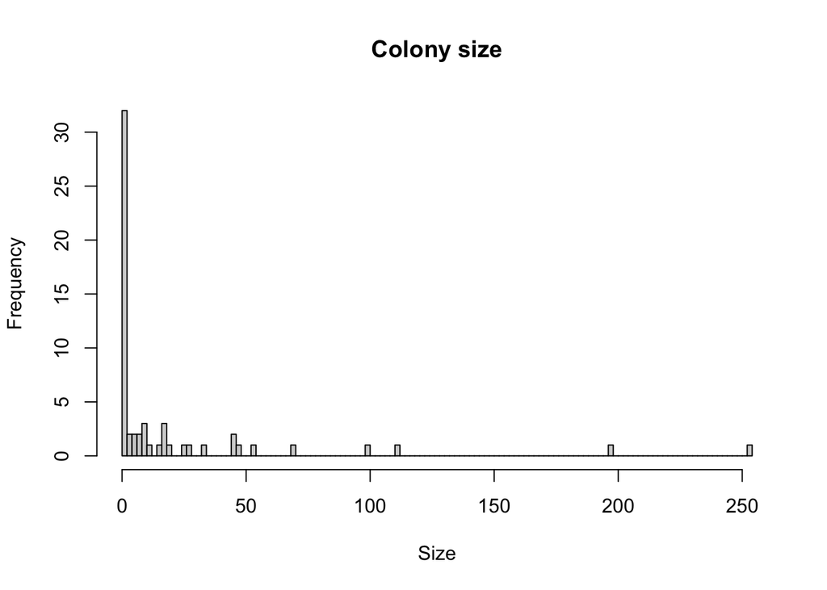

Map (excluding 0)

[interactive chart not shown]

### 2024 Survey methods

```
'data.frame':   6 obs. of  3 variables:
 $ Name     : chr  "Deep Bay Marine Boat Ramp" "Sechelt Boat Ramp" "Charlaine Boat Ramp" "Kinsmen Beach Boat Ramp" ...
 $ Latitude : num  49.5 49.5 49.2 48.9 49.4 ...
 $ Longitude: num  -125 -124 -124 -124 -123 ...
```

After assessing the above information we proceed to set some thresholds to select the final set of colonies to survey in 2024.

- include breeding locations with active breeding (>= 1 pair) starting from 2004.
- include breeding locations which have records before 2004 with >= 500 breeding pairs.

black: selected colonies (n =80) in black. grey: not selected targets. yellow center: covered by others (i.e. not needed to be surveyed by us) and dark green outer ring: National Park, medium green = Provincial Park and light green = Ecological Reserve.

[interactive chart not shown]

#### Priorities

1) breeding survey selected sites

2a) add extra ‘en route’ sites

2b) add clutch size and egg size

2c) ground truthing: both fly and count on foot

### elevation map for UAV mission planning

[interactive chart not shown]

### Next steps

This is just a quick and dirty visualization exercise and we can tune it for our needs. For example:

- add which colonies can be done by UAV from land.
- zones to be done by boat
- detailed timeline with launch locations, etc